# The forecaster’s toolbox

2. Facebook stock price

```r
fb_stock <- gafa_stock %>%
  filter(Symbol == "FB")
fb_stock
```

```
## # A tsibble: 1,258 x 8 [!]
## # Key:       Symbol [1]
##    Symbol Date        Open  High   Low Close Adj_Close   Volume
##    <chr>  <date>     <dbl> <dbl> <dbl> <dbl>     <dbl>    <dbl>
##  1 FB     2014-01-02  54.8  55.2  54.2  54.7      54.7 43195500
##  2 FB     2014-01-03  55.0  55.7  54.5  54.6      54.6 38246200
##  3 FB     2014-01-06  54.4  57.3  54.0  57.2      57.2 68852600
##  4 FB     2014-01-07  57.7  58.5  57.2  57.9      57.9 77207400
##  5 FB     2014-01-08  57.6  58.4  57.2  58.2      58.2 56682400
##  6 FB     2014-01-09  58.7  59.0  56.7  57.2      57.2 92253300
##  7 FB     2014-01-10  57.1  58.3  57.1  57.9      57.9 42449500
##  8 FB     2014-01-13  57.9  58.2  55.4  55.9      55.9 63010900
##  9 FB     2014-01-14  56.5  57.8  56.1  57.7      57.7 37503600
## 10 FB     2014-01-15  58.0  58.6  57.3  57.6      57.6 33663400
## # ... with 1,248 more rows
```

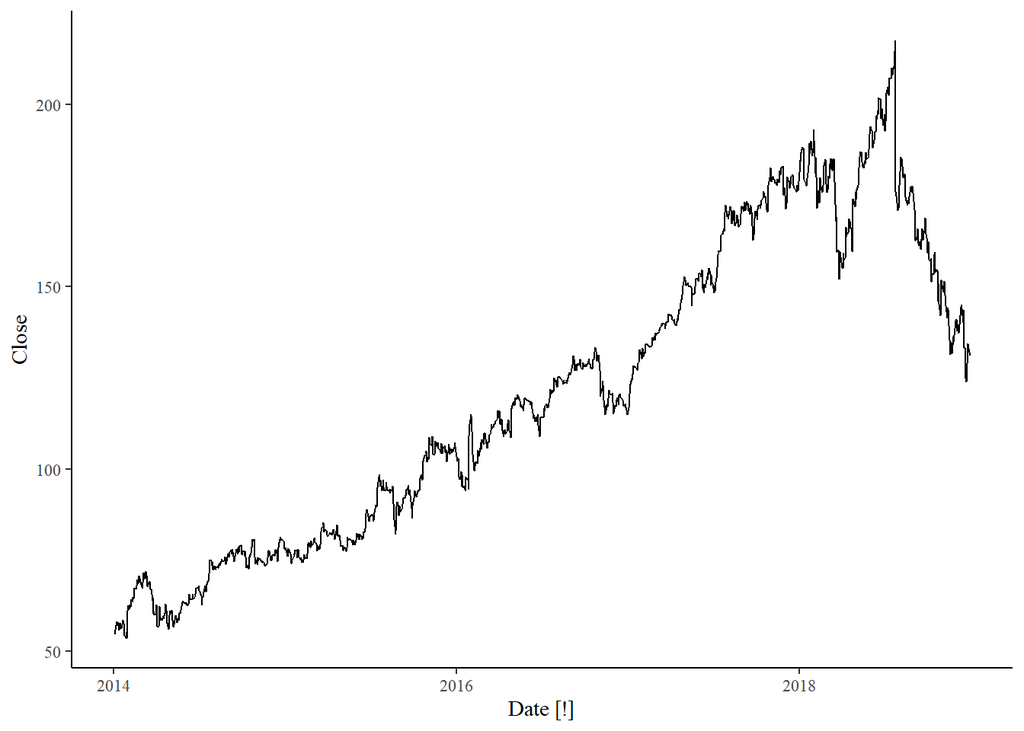

```r
fb_stock %>% autoplot(Close)
```

```r
fb_stock <- fb_stock %>%
  mutate(day = row_number()) %>%
  update_tsibble(index = day, regular = TRUE)
```

```r
x_1 = fb_stock$day %>% min()
x_2 = fb_stock$day %>% max()

y_1 = fb_stock %>%
  filter(day == min(day)) %>%
  as_tibble() %>%
  pull(Close)

y_2 = fb_stock %>%
  filter(day == max(day)) %>%
  as_tibble() %>%
  pull(Close)

x_1 # First day
```

```
## [1] 1
```

```r
x_2 # Last day
```

```
## [1] 1258
```

```r
y_1 # Value first day
```

```
## [1] 54.71
```

```r
y_2 # Value last day
```

```
## [1] 131.09
```

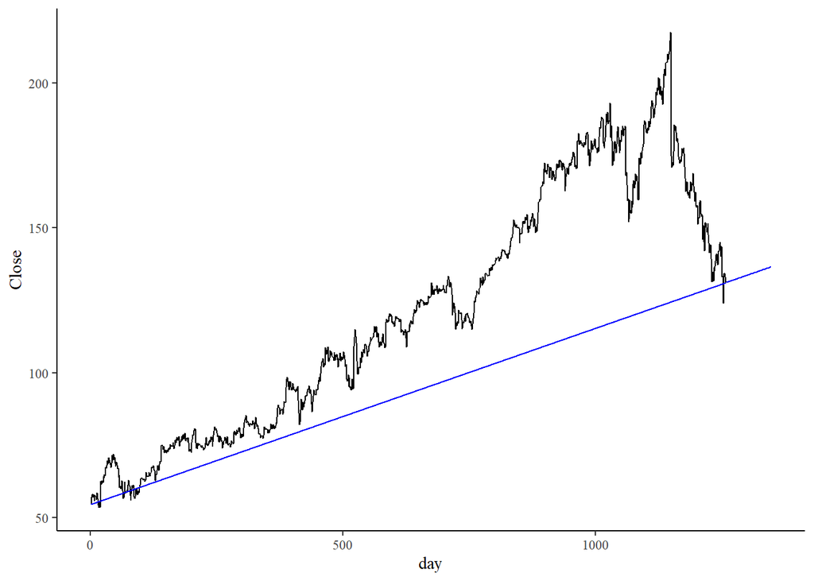

```r
fb_stock %>%
  model(
    Drift = RW(Close ~ drift())
  ) %>%
  forecast(h = 90) %>%
  autoplot(fb_stock, level = NULL) +
  geom_segment(aes(x = x_1, y = y_1, xend = x_2, yend = y_2), color="blue")
```

Or you could just take the mathematical equation in that other chapter to show that the drift forecast are actually a continuation of the line between the values of the first and last observations.

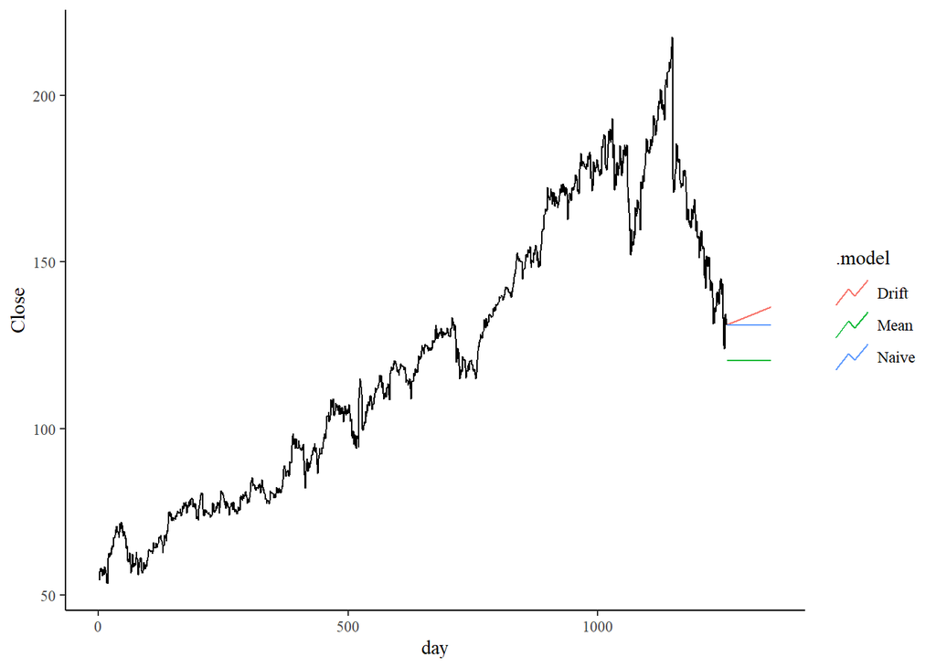

```r
fb_stock %>%
  model(
    Naive = NAIVE(Close),
    Mean = MEAN(Close),
    Drift = RW(Close ~ drift())
  ) %>%
  forecast(h = 90) %>%
  autoplot(fb_stock, level = NULL)
```

At the very least, Mean or Naive should be better than drift, since the stock is on a decreasing trend.

3. Quarterly Australian beer production

```r
# Extract data of interest
recent_production <- aus_production %>%
  filter(year(Quarter) >= 1992)
# Define and estimate a model
fit <- recent_production %>% model(SNAIVE(Beer))
```

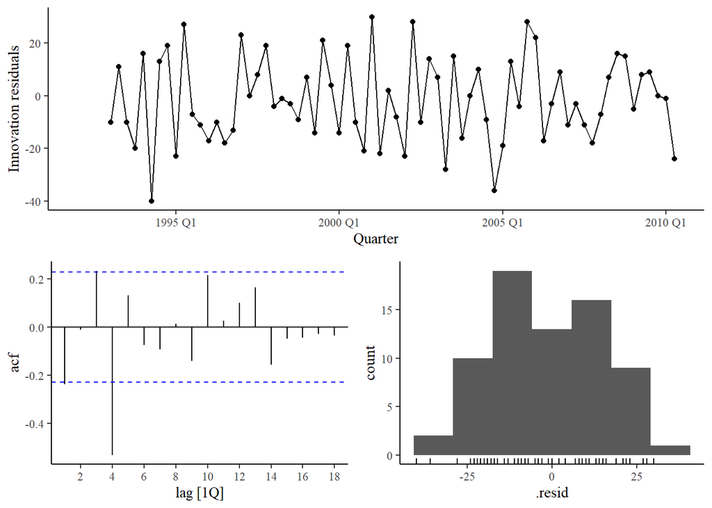

```r
# Look at the residuals
fit %>% gg_tsresiduals()
```

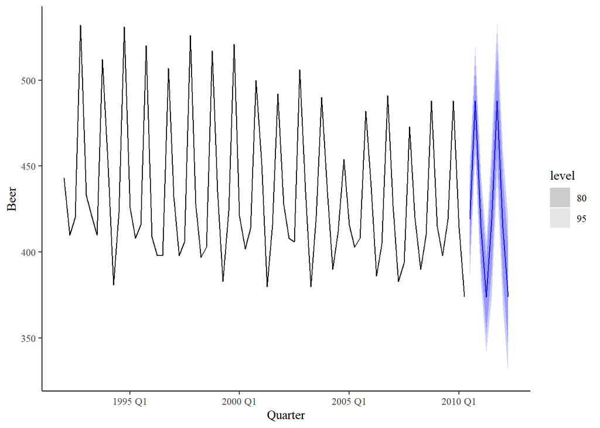

```r
# Look a some forecasts
fit %>% forecast() %>% autoplot(recent_production)
```

Well, there does seem to be some negative auto correlation.

```r
fit %>%
  augment() %>%
  features(.innov, ljung_box, lag = 4, dof = 0)
```

```
## # A tibble: 1 x 3
##   .model       lb_stat  lb_pvalue
##   <chr>          <dbl>      <dbl>
## 1 SNAIVE(Beer)    29.8 0.00000546
```

That settles it.

4. Australian Exports

```r
aus_exports <- global_economy %>%
  filter(Country == "Australia") %>%
  select(Year, Country, Exports)
aus_exports
```

```
## # A tsibble: 58 x 3 [1Y]
## # Key:       Country [1]
##     Year Country   Exports
##    <dbl> <fct>       <dbl>
##  1  1960 Australia    13.0
##  2  1961 Australia    12.4
##  3  1962 Australia    13.9
##  4  1963 Australia    13.0
##  5  1964 Australia    14.9
##  6  1965 Australia    13.2
##  7  1966 Australia    12.9
##  8  1967 Australia    12.9
##  9  1968 Australia    12.3
## 10  1969 Australia    12.0
## # ... with 48 more rows
```

```r
aus_bricks <- aus_production %>%
  select(Bricks) %>%
  drop_na()
aus_bricks
```

```
## # A tsibble: 198 x 2 [1Q]
##    Bricks Quarter
##     <dbl>   <qtr>
##  1    189 1956 Q1
##  2    204 1956 Q2
##  3    208 1956 Q3
##  4    197 1956 Q4
##  5    187 1957 Q1
##  6    214 1957 Q2
##  7    227 1957 Q3
##  8    222 1957 Q4
##  9    199 1958 Q1
## 10    229 1958 Q2
## # ... with 188 more rows
```

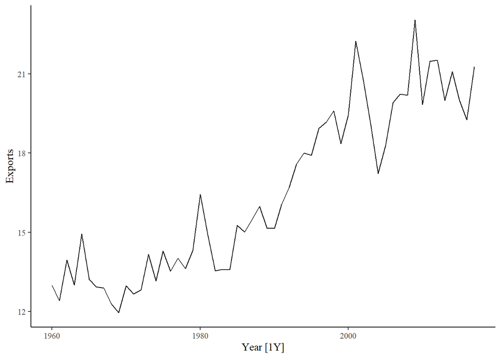

```r
aus_exports %>%
  autoplot(Exports)
```

Not much seasonality (plus, we only have years)

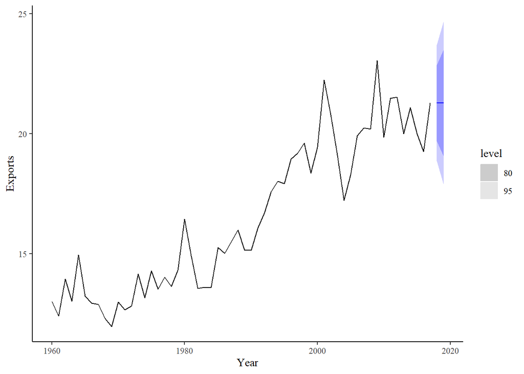

```r
aus_exports_fit <- aus_exports %>%
  model(Naive = NAIVE(Exports))

aus_exports_fit %>%
  forecast() %>%
  autoplot(aus_exports)
```

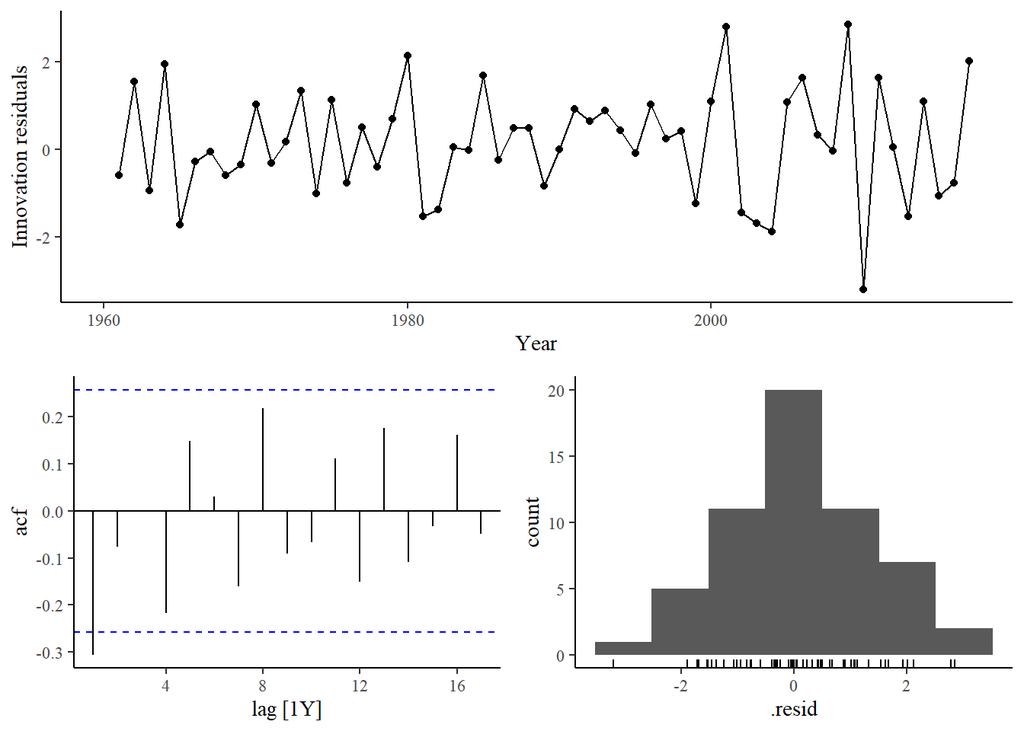

```r
aus_exports_fit %>%
  gg_tsresiduals()
```

```r
aus_exports_fit %>%
  augment() %>%
  features(.innov, ljung_box, lag = 1, dof = 0)
```

```
## # A tibble: 1 x 4
##   Country   .model lb_stat lb_pvalue
##   <fct>     <chr>    <dbl>     <dbl>
## 1 Australia Naive     5.63    0.0177
```

First order autocorrelation (if I’m not mistaken?) OK, so after some research, the Ljung-Box is [contested by some econometricians](https://stats.stackexchange.com/questions/148004/testing-for-autocorrelation-ljung-box-versus-breusch-godfrey) in autoregressive models. Considering a Naive model is y_t = y_t-1 + e, isn’t it a specific kind of AR1 model?

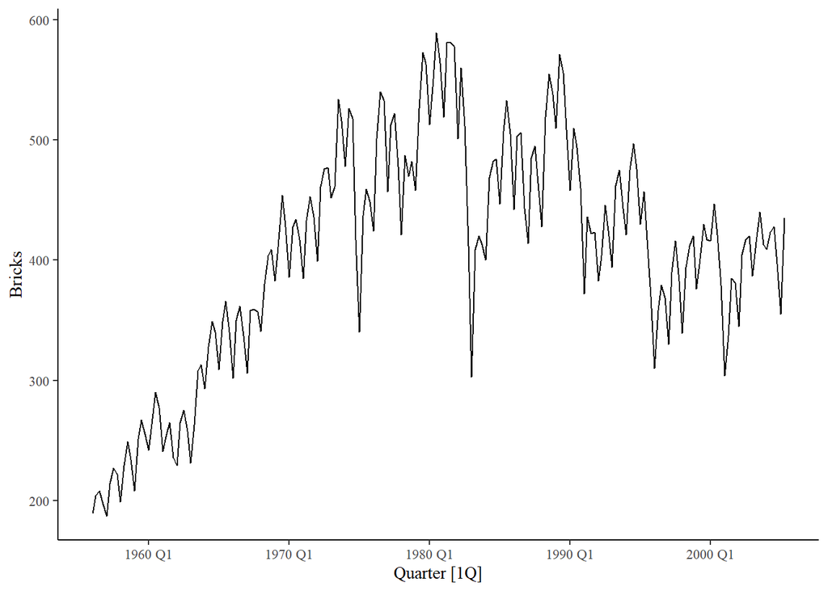

```r
aus_bricks %>%
  autoplot(Bricks)
```

```r
aus_bricks %>%
  gg_season()
```

```
## Plot variable not specified, automatically selected `y = Bricks`
```

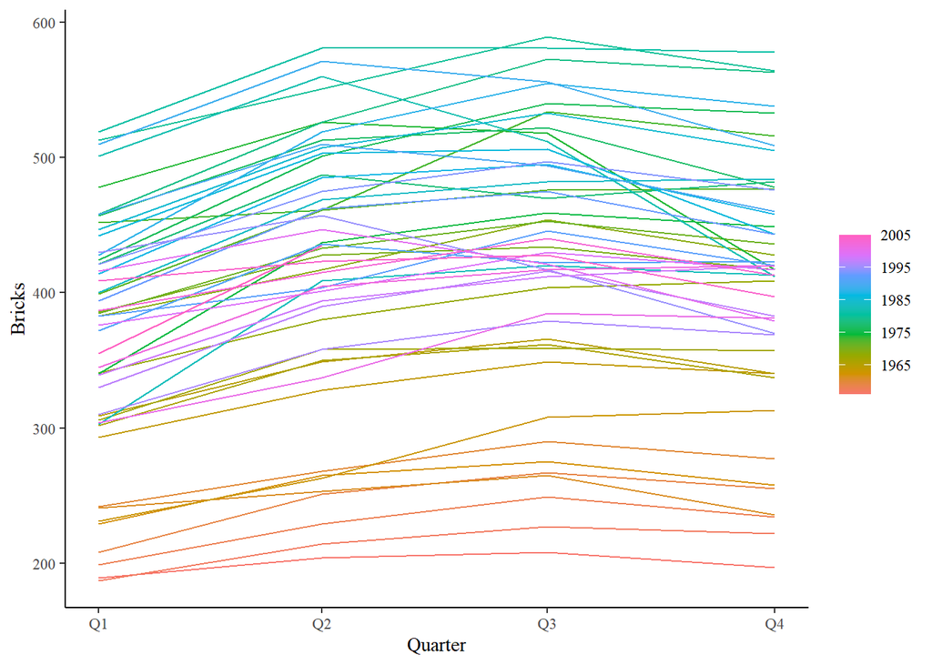

```r
aus_bricks_fit <- aus_bricks %>%
  model(Snaive = SNAIVE(Bricks ~ lag("year")))
```

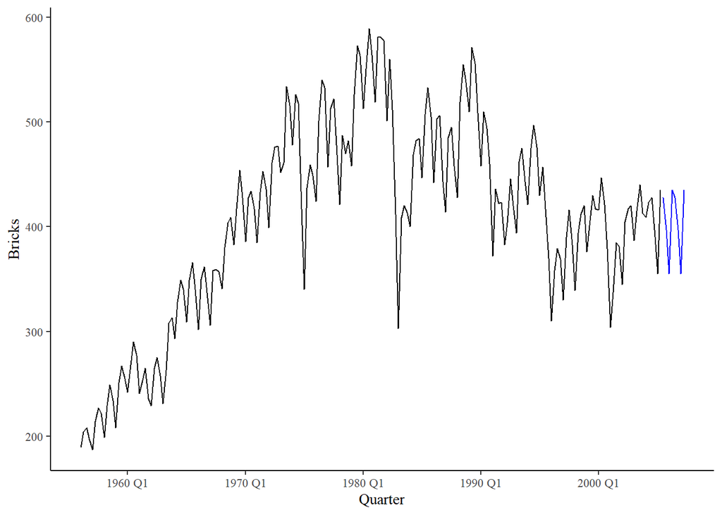

```r
aus_bricks_fit %>%
  forecast() %>%
  autoplot(aus_bricks, level = NULL)
```

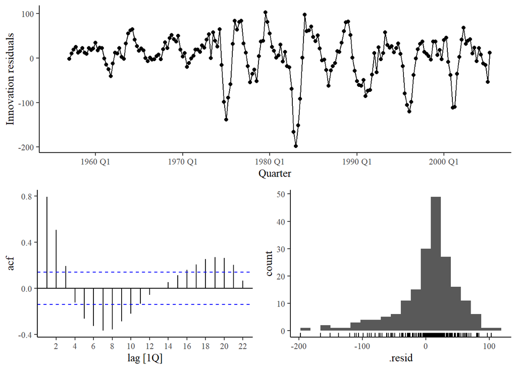

```r
aus_bricks_fit %>%
  gg_tsresiduals()
```

No need to run a test here.

5. Aus_livestock

```
## Plot variable not specified, automatically selected `.vars = Count`
```

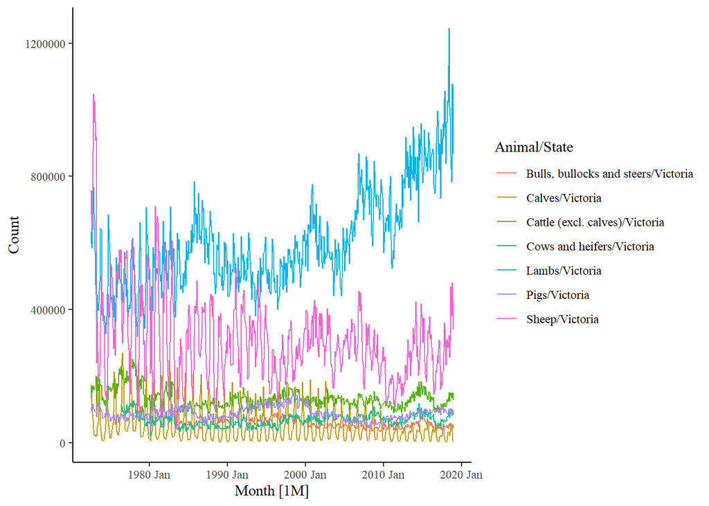

```r
aus_livestock_victoria <- aus_livestock %>%
  filter(State == "Victoria")
aus_livestock_victoria %>%
  autoplot()
```

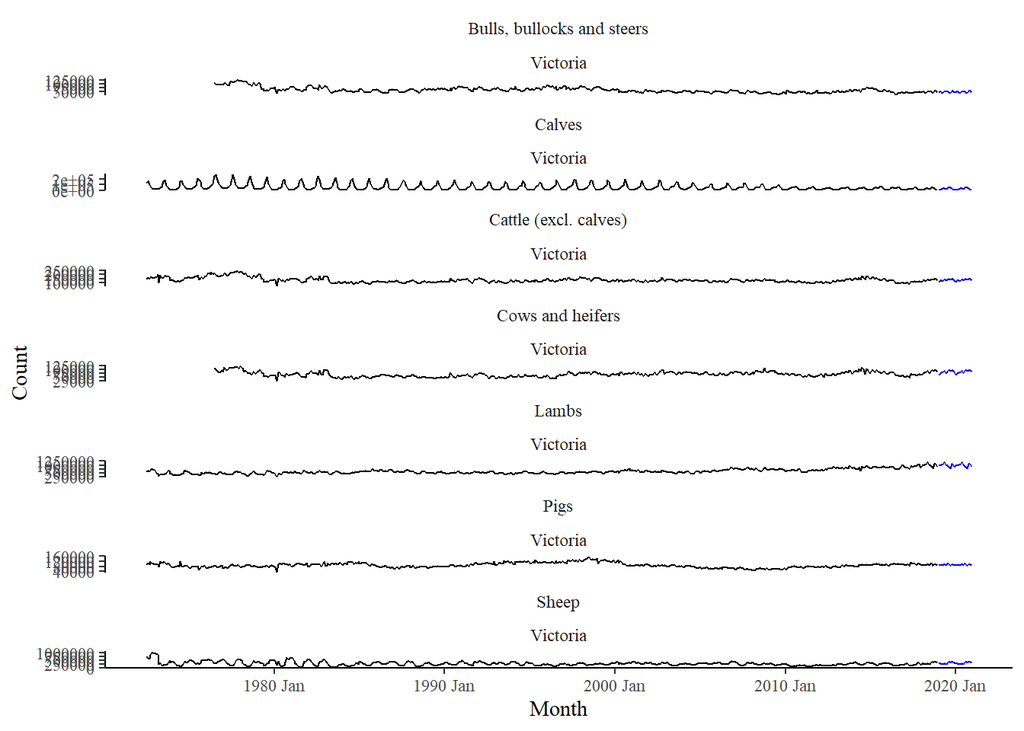

```r
aus_livestock_victoria %>%
  model(
    SNAIVE = SNAIVE(Count)
  ) %>%
  forecast() %>%
  autoplot(aus_livestock_victoria, level = NULL)
```

```r
ggsave("aus_livestock_victoria.jpg", width = 3000, height = 4000, unit = "px")
```

It’s reasonable. It could be better with a slight drift, for some time series.

7. Retail

```r
set.seed(451)
aus_retail_sample <- aus_retail %>%
  filter(`Series ID` == sample(aus_retail$`Series ID`, 1))
aus_retail_sample
```

```
## # A tsibble: 441 x 5 [1M]
## # Key:       State, Industry [1]
##    State           Industry        `Series ID`    Month Turnover
##    <chr>           <chr>           <chr>          <mth>    <dbl>
##  1 New South Wales Other retailing A3349872X   1982 Apr     178
##  2 New South Wales Other retailing A3349872X   1982 May     182.
##  3 New South Wales Other retailing A3349872X   1982 Jun     174.
##  4 New South Wales Other retailing A3349872X   1982 Jul     180.
##  5 New South Wales Other retailing A3349872X   1982 Aug     178.
##  6 New South Wales Other retailing A3349872X   1982 Sep     176.
##  7 New South Wales Other retailing A3349872X   1982 Oct     180.
##  8 New South Wales Other retailing A3349872X   1982 Nov     193.
##  9 New South Wales Other retailing A3349872X   1982 Dec     260.
## 10 New South Wales Other retailing A3349872X   1983 Jan     182.
## # ... with 431 more rows
```

```
## Plot variable not specified, automatically selected `.vars = Turnover`
```

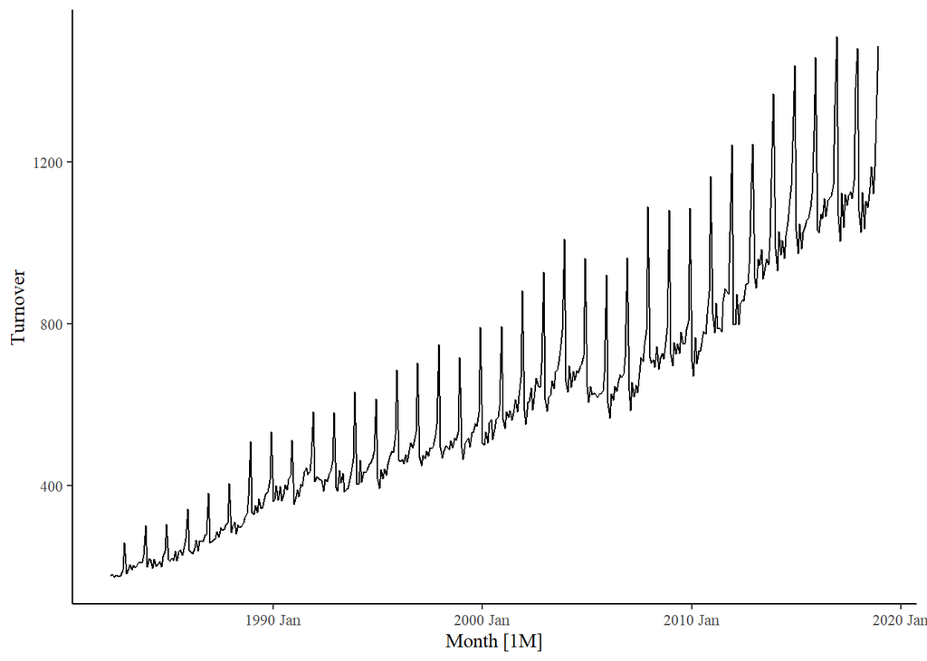

```r
aus_retail_sample %>% autoplot()
```

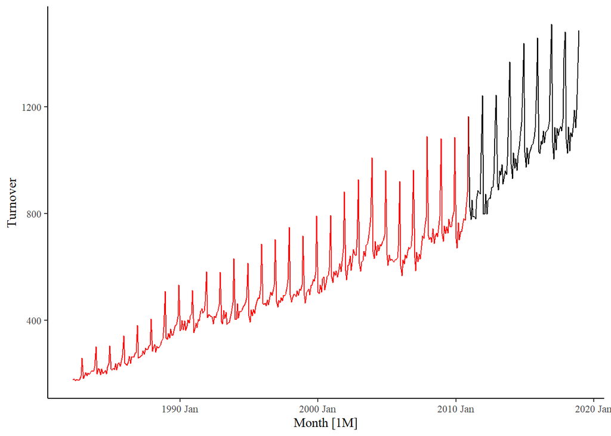

```r
aus_retail_sample_train <- aus_retail_sample %>%
  filter(year(Month) < 2011)

autoplot(aus_retail_sample, Turnover) +
  autolayer(aus_retail_sample_train, Turnover, colour = "red")
```

```r
aus_retail_sample_train %>% tail()
```

```
## # A tsibble: 6 x 5 [1M]
## # Key:       State, Industry [1]
##   State           Industry        `Series ID`    Month Turnover
##   <chr>           <chr>           <chr>          <mth>    <dbl>
## 1 New South Wales Other retailing A3349872X   2010 Jul     764.
## 2 New South Wales Other retailing A3349872X   2010 Aug     783.
## 3 New South Wales Other retailing A3349872X   2010 Sep     775
## 4 New South Wales Other retailing A3349872X   2010 Oct     824.
## 5 New South Wales Other retailing A3349872X   2010 Nov     881.
## 6 New South Wales Other retailing A3349872X   2010 Dec    1164.
```

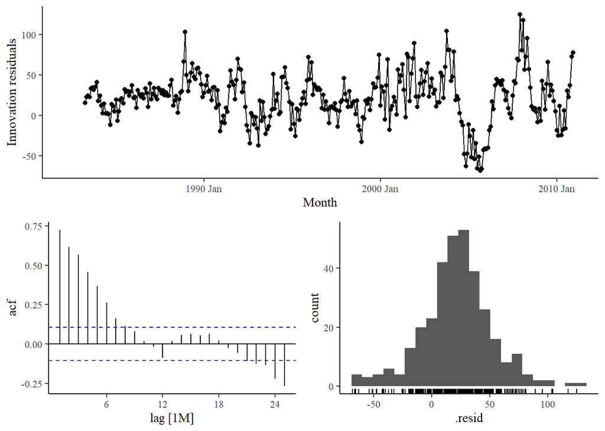

```r
aus_retail_sample_fit <- aus_retail_sample_train %>%
  model(SNAIVE(Turnover))

aus_retail_sample_fit %>% gg_tsresiduals()
```

Everything is wrong: heteroskedasticity, autocorrelation and the errors are not normally distributed

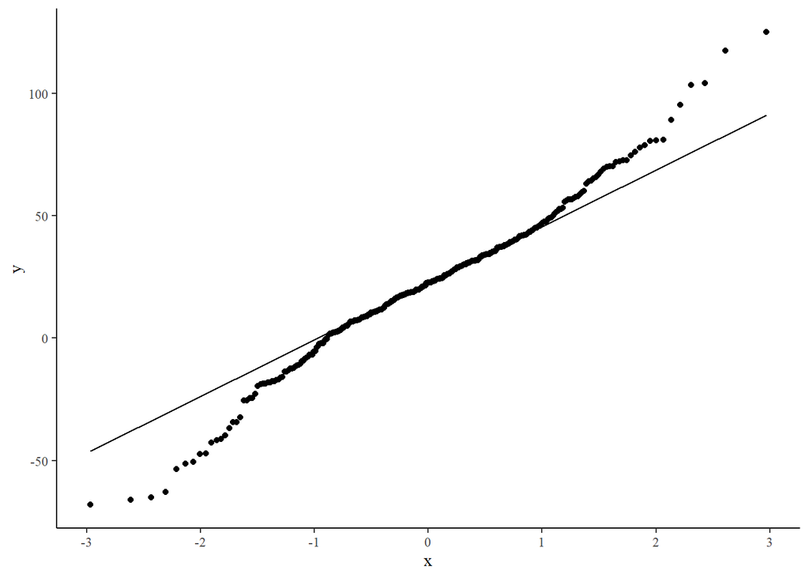

```r
aus_retail_sample_fit %>%
  augment() %>%
  ggplot(
    aes(
      sample = .innov
    )
  ) +
  stat_qq() +
  stat_qq_line()
```

```r
aus_retail_sample_fit %>%
  augment() %>%
  drop_na() %>%
  pull(.innov) %>%
  shapiro.test()
```

```
##
##  Shapiro-Wilk normality test
##
## data:  .
## W = 0.98323, p-value = 0.000635
```

That settles it.

```r
aus_retail_sample_fc <- aus_retail_sample_fit %>%
  forecast(new_data = anti_join(aus_retail_sample, aus_retail_sample_train))
```

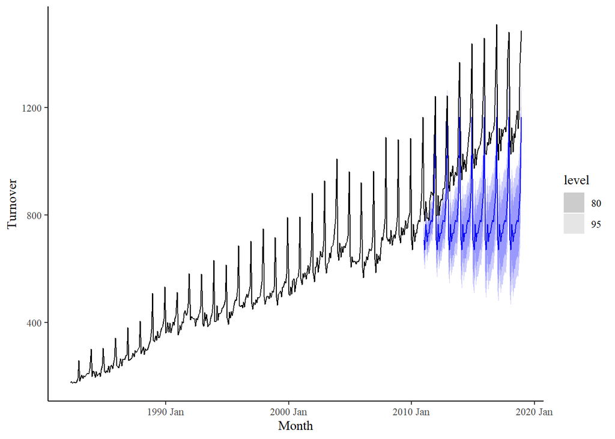

```r
aus_retail_sample_fc %>% autoplot(aus_retail_sample)
```

Haha.

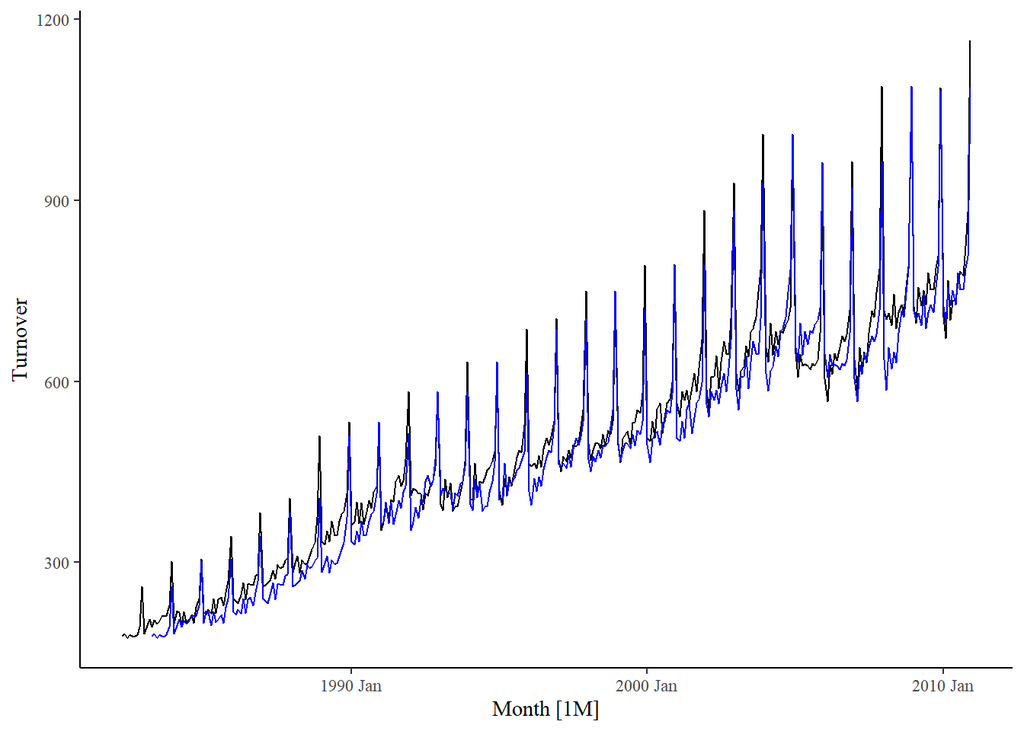

```r
aus_retail_sample_fit %>%
  augment() %>%
  autoplot(Turnover) +
  autolayer(aus_retail_sample_fit %>% augment(), .fitted, colour = "blue")
```

```r
aus_retail_sample_fit %>% accuracy()
```

```
## # A tibble: 1 x 12
##   State  Industry  .model  .type    ME  RMSE   MAE   MPE  MAPE  MASE RMSSE  ACF1
##   <chr>  <chr>     <chr>   <chr> <dbl> <dbl> <dbl> <dbl> <dbl> <dbl> <dbl> <dbl>
## 1 New S~ Other re~ SNAIVE~ Trai~  21.7  36.9  29.9  4.82  6.26     1     1 0.725
```

```r
aus_retail_sample_fc %>% accuracy(aus_retail_sample)
```

```
## # A tibble: 1 x 12
##   .model   State  Industry .type    ME  RMSE   MAE   MPE  MAPE  MASE RMSSE  ACF1
##   <chr>    <chr>  <chr>    <chr> <dbl> <dbl> <dbl> <dbl> <dbl> <dbl> <dbl> <dbl>
## 1 SNAIVE(~ New S~ Other r~ Test   261.  283.  261.  24.2  24.2  8.75  7.68 0.828
```

Not good.

8. aus_livestock

```r
pigs_nsw <- aus_livestock %>%
  filter(Animal == "Pigs" & State == "New South Wales")
pigs_nsw
```

```
## # A tsibble: 558 x 4 [1M]
## # Key:       Animal, State [1]
##       Month Animal State            Count
##       <mth> <fct>  <fct>            <dbl>
##  1 1972 Jul Pigs   New South Wales  97400
##  2 1972 Aug Pigs   New South Wales 114700
##  3 1972 Sep Pigs   New South Wales 109900
##  4 1972 Oct Pigs   New South Wales 108300
##  5 1972 Nov Pigs   New South Wales 122200
##  6 1972 Dec Pigs   New South Wales 106900
##  7 1973 Jan Pigs   New South Wales  96600
##  8 1973 Feb Pigs   New South Wales  96700
##  9 1973 Mar Pigs   New South Wales 121200
## 10 1973 Apr Pigs   New South Wales  99300
## # ... with 548 more rows
```

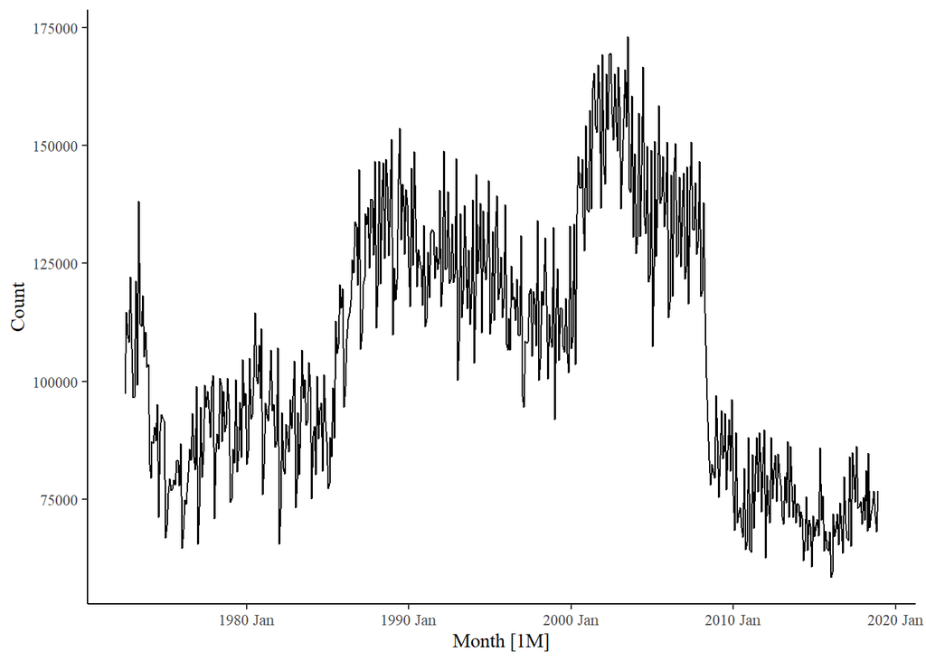

```r
pigs_nsw %>% autoplot(Count)
```

2008 hit hard.

```r
pigs_nsw %>% gg_season()
```

```
## Plot variable not specified, automatically selected `y = Count`
```

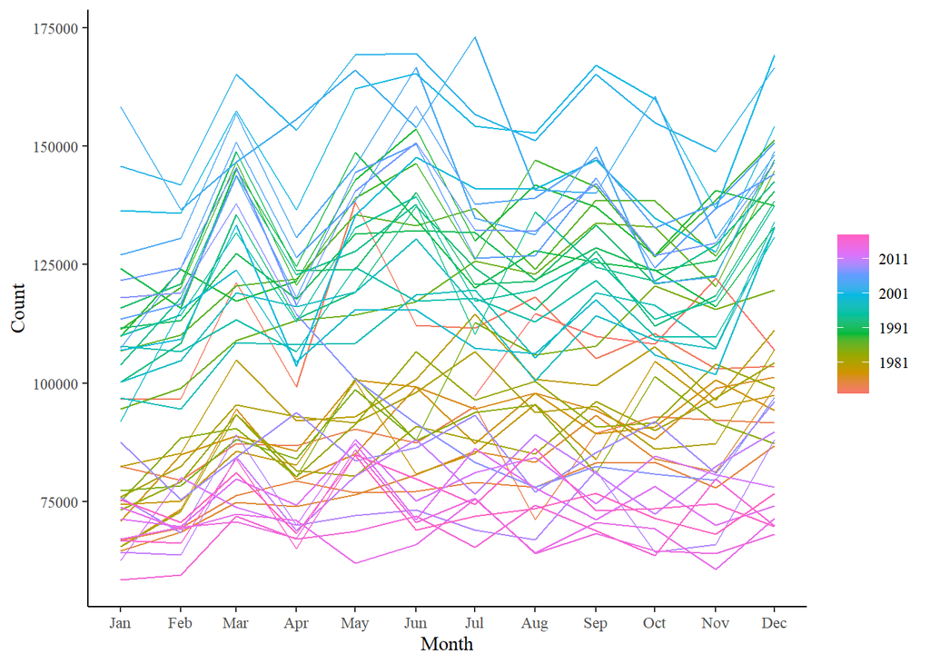

Nothing obvious there.

```r
df_size = nrow(pigs_nsw)
test_size = 72
train_size = df_size - test_size

pigs_nsw_train <- pigs_nsw %>%
  slice(
    1:train_size
  )
pigs_nsw_test <- pigs_nsw %>%
  slice(
    (train_size+1):df_size
  )
```

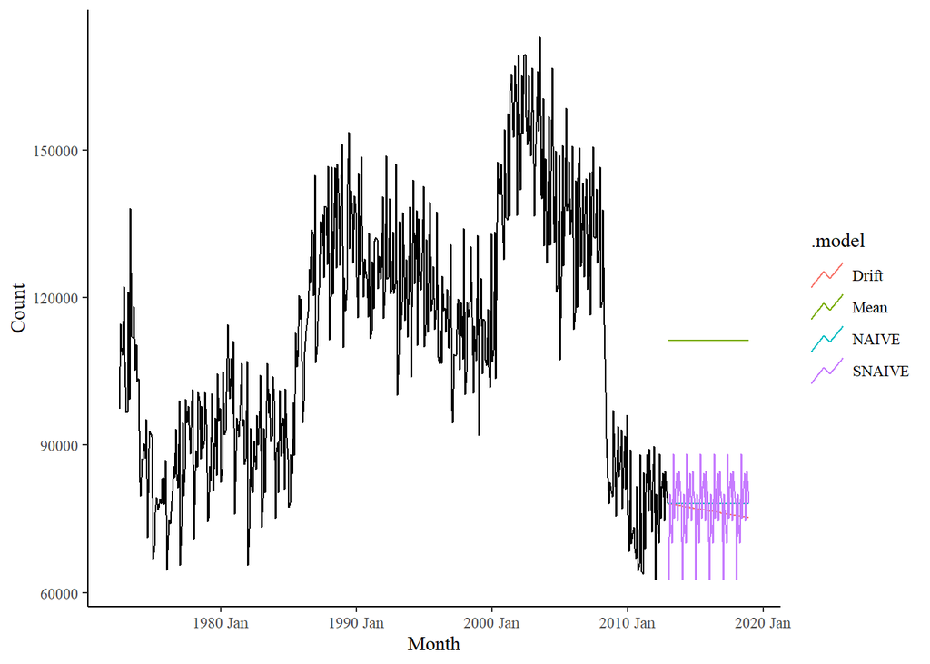

```r
pigs_nsw_train_fit <- pigs_nsw_train %>%
  model(
    NAIVE = NAIVE(Count),
    SNAIVE = SNAIVE(Count),
    Mean = MEAN(Count),
    Drift = RW(Count ~ drift())
  )

pigs_nsw_train_fc <- pigs_nsw_train_fit %>% forecast(new_data=pigs_nsw_test)
pigs_nsw_train_fc %>% autoplot(pigs_nsw_train, level = NULL)
```

```r
pigs_nsw_train_fit %>% accuracy() %>% arrange(RMSE)
```

```
## # A tibble: 4 x 12
##   Animal State     .model .type        ME   RMSE    MAE    MPE  MAPE  MASE RMSSE
##   <fct>  <fct>     <chr>  <chr>     <dbl>  <dbl>  <dbl>  <dbl> <dbl> <dbl> <dbl>
## 1 Pigs   New Sout~ SNAIVE Trai~ -8.23e+ 2 14530. 10600  -1.83   10.1  1     1
## 2 Pigs   New Sout~ Drift  Trai~  3.01e-12 15324. 12173. -0.985  11.2  1.15  1.05
## 3 Pigs   New Sout~ NAIVE  Trai~ -3.98e+ 1 15324. 12171. -1.02   11.2  1.15  1.05
## 4 Pigs   New Sout~ Mean   Trai~  2.42e-12 25389. 21496. -5.59   20.8  2.03  1.75
## # ... with 1 more variable: ACF1 <dbl>
```

```r
pigs_nsw_train_fc %>% accuracy(pigs_nsw_test)
```

```
## # A tibble: 4 x 12
##   .model Animal State       .type      ME   RMSE    MAE    MPE  MAPE  MASE RMSSE
##   <chr>  <fct>  <fct>       <chr>   <dbl>  <dbl>  <dbl>  <dbl> <dbl> <dbl> <dbl>
## 1 Drift  Pigs   New South ~ Test   -4685.  8091.  6967.  -7.36  10.1   NaN   NaN
## 2 Mean   Pigs   New South ~ Test  -39360. 39894. 39360. -55.9   55.9   NaN   NaN
## 3 NAIVE  Pigs   New South ~ Test   -6138.  8941.  7840.  -9.39  11.4   NaN   NaN
## 4 SNAIVE Pigs   New South ~ Test   -5838. 10111.  8174.  -8.81  11.9   NaN   NaN
## # ... with 1 more variable: ACF1 <dbl>
```

```r
pigs_nsw_train_fc %>%
  rename(Count_fc = Count) %>%
  left_join(pigs_nsw_test) %>%
  rename(Count_true = Count)
```

```
## # A tsibble: 288 x 7 [1M]
## # Key:       Animal, State, .model [4]
##    Animal State           .model    Month          Count_fc  .mean Count_true
##    <fct>  <fct>           <chr>     <mth>            <dist>  <dbl>      <dbl>
##  1 Pigs   New South Wales Drift  2013 Jan N(78060, 2.4e+08) 78060.      71300
##  2 Pigs   New South Wales Drift  2013 Feb N(78020, 4.7e+08) 78020.      69700
##  3 Pigs   New South Wales Drift  2013 Mar N(77981, 7.1e+08) 77981.      79900
##  4 Pigs   New South Wales Drift  2013 Apr N(77941, 9.5e+08) 77941.      74300
##  5 Pigs   New South Wales Drift  2013 May N(77901, 1.2e+09) 77901.      87200
##  6 Pigs   New South Wales Drift  2013 Jun N(77861, 1.4e+09) 77861.      71200
##  7 Pigs   New South Wales Drift  2013 Jul N(77821, 1.7e+09) 77821.      86200
##  8 Pigs   New South Wales Drift  2013 Aug N(77782, 1.9e+09) 77782.      78000
##  9 Pigs   New South Wales Drift  2013 Sep N(77742, 2.2e+09) 77742.      71200
## 10 Pigs   New South Wales Drift  2013 Oct N(77702, 2.4e+09) 77702.      78200
## # ... with 278 more rows
```

```
## Plot variable not specified, automatically selected `.vars = Count`
```

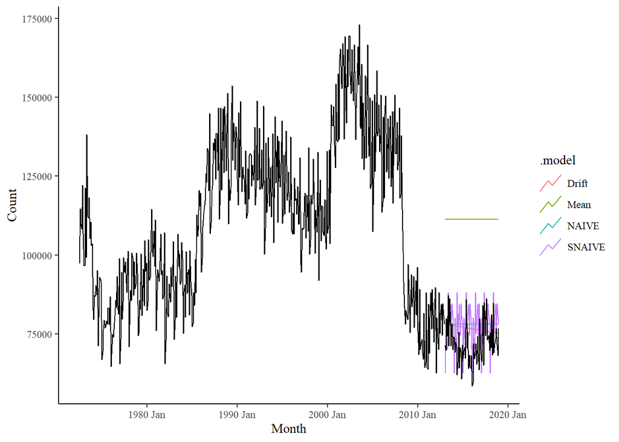

```r
pigs_nsw_train_fc %>%
  autoplot(pigs_nsw_train, level = NULL) +
  autolayer(pigs_nsw_test)
```

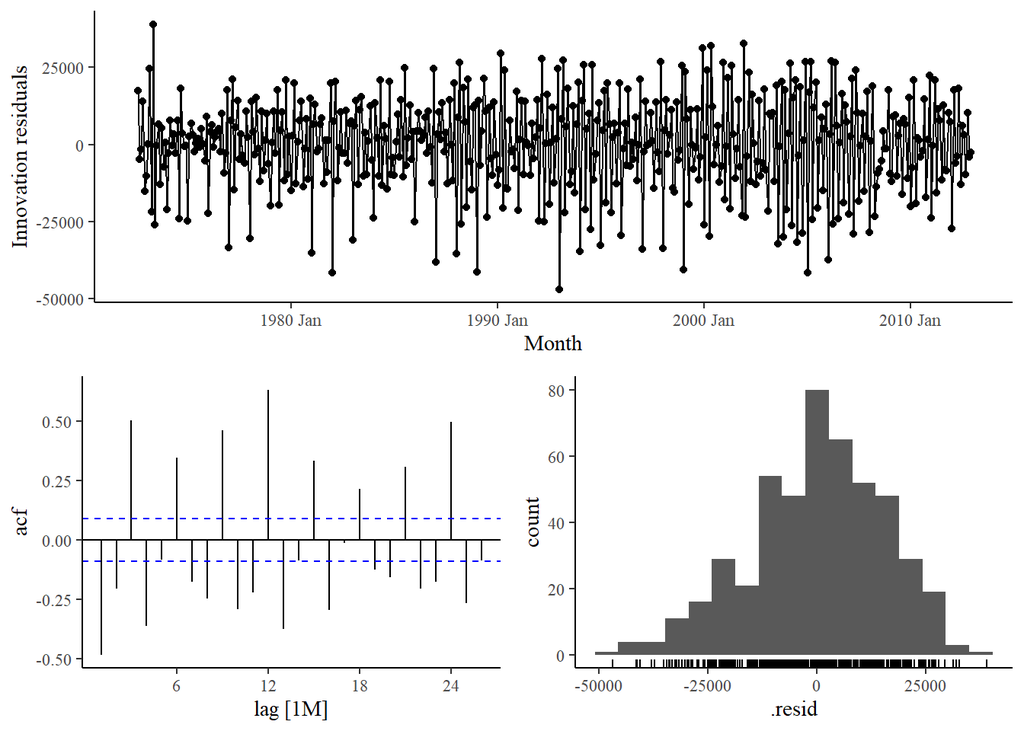

```r
pigs_nsw_train_fit %>% select(Animal, State, Drift) %>% gg_tsresiduals()
```

Not white noise.

Exercises 9 and 10 are similar to 8. I’ll skip them.

11. Bricks, again

```r
bricks <- aus_production %>%
  select(Quarter, Bricks) %>%
  drop_na()
bricks
```

```
## # A tsibble: 198 x 2 [1Q]
##    Quarter Bricks
##      <qtr>  <dbl>
##  1 1956 Q1    189
##  2 1956 Q2    204
##  3 1956 Q3    208
##  4 1956 Q4    197
##  5 1957 Q1    187
##  6 1957 Q2    214
##  7 1957 Q3    227
##  8 1957 Q4    222
##  9 1958 Q1    199
## 10 1958 Q2    229
## # ... with 188 more rows
```

```
## Plot variable not specified, automatically selected `.vars = Bricks`
```

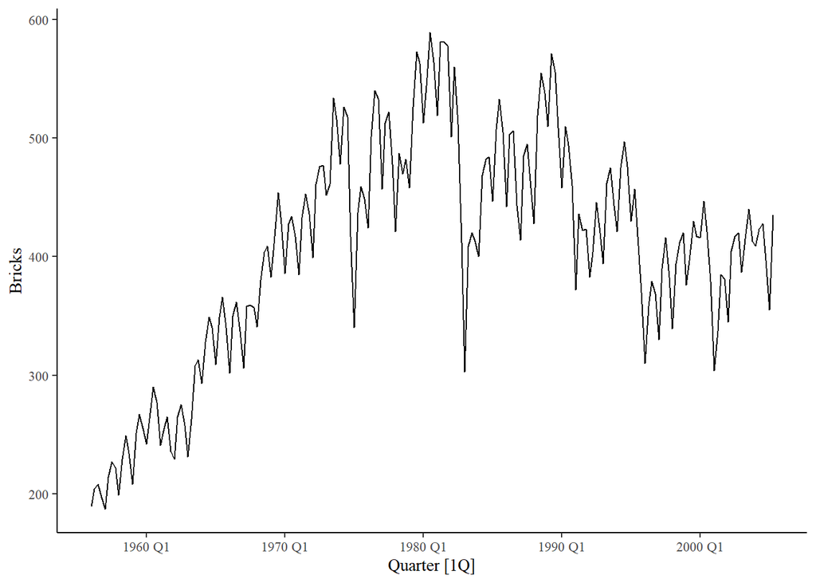

```r
bricks %>% autoplot()
```

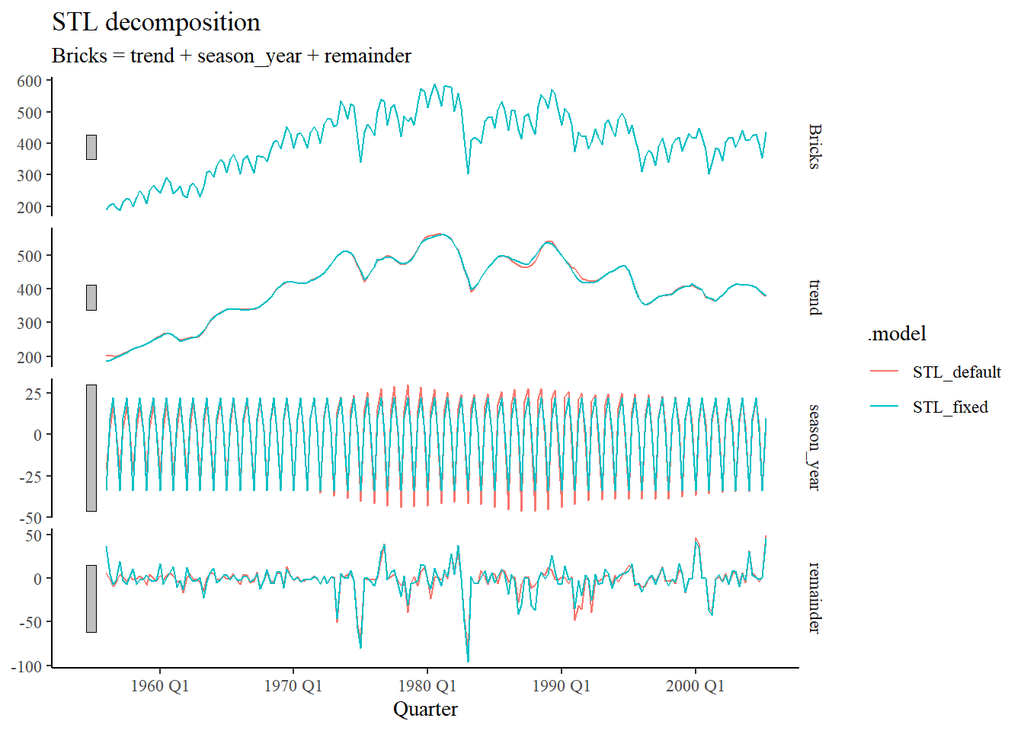

```r
bricks_stl <- bricks %>%
  model(
    STL_default = STL(Bricks, robust = TRUE),
    STL_fixed = STL(Bricks ~ trend() + season(window="periodic"), robust = TRUE)
    )
bricks_stl %>%
  components() %>%
  autoplot()
```

Changing seasonality makes more sense, considering there is more variation around the 1980s.

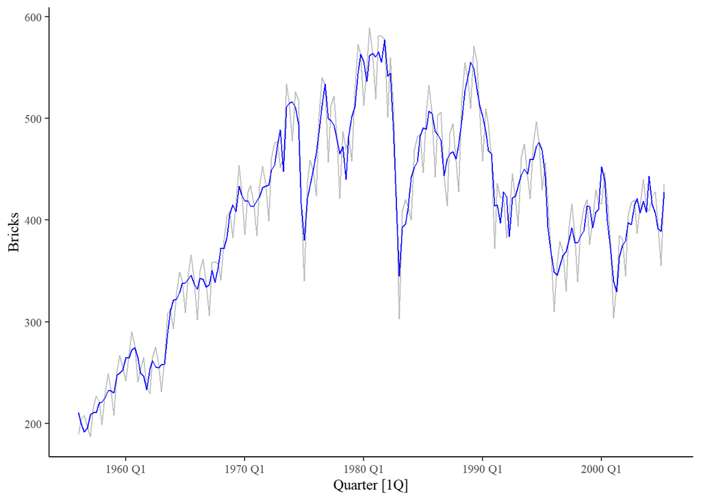

```r
bricks_stl %>%
  components() %>%
  filter(.model == "STL_default") %>%
  select(Quarter, Bricks, season_adjust) %>%
  autoplot(Bricks, colour = "gray") +
  geom_line(
    aes(y = season_adjust),
    colour = "blue"
  )
```

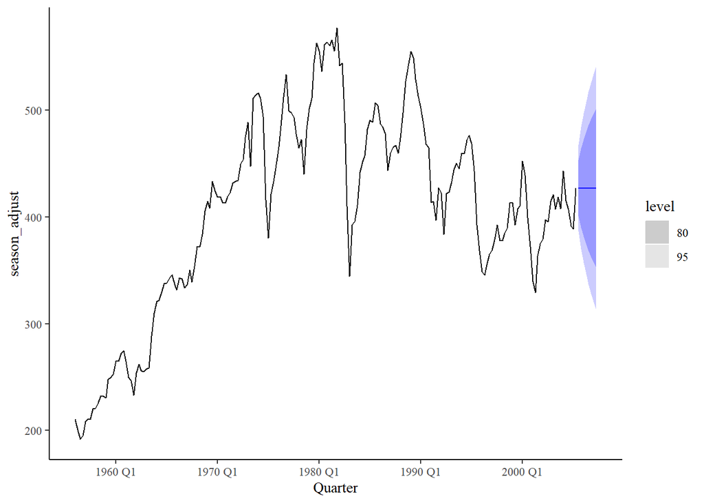

```r
bricks_stl_default <- bricks_stl %>%
  select(STL_default) %>%
  components() %>%
  select(-.model)

bricks_stl_default %>%
  model(
    Naive = NAIVE(season_adjust)
  ) %>%
  forecast() %>%
  autoplot(bricks_stl_default)
```

With decomposition_model():

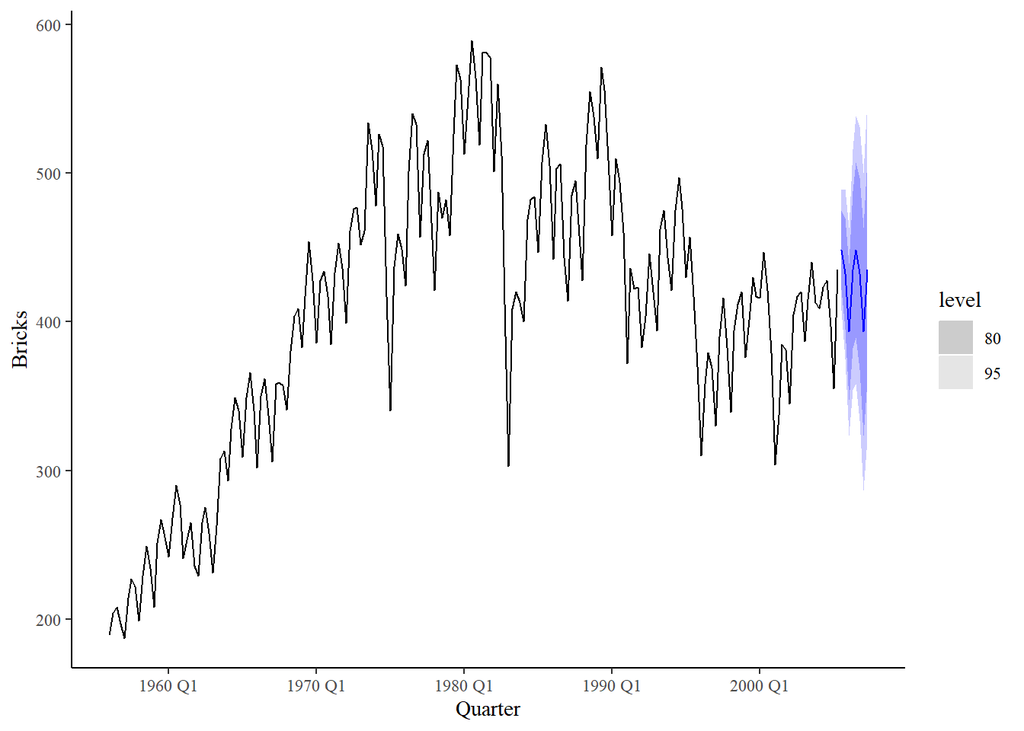

```r
bricks_dcmp <- bricks %>%
  model(
    STL_forecast = decomposition_model(
      STL(Bricks, robust = TRUE),
      NAIVE(season_adjust)
    )
  )

bricks_dcmp %>%
  forecast() %>%
  autoplot(bricks)
```

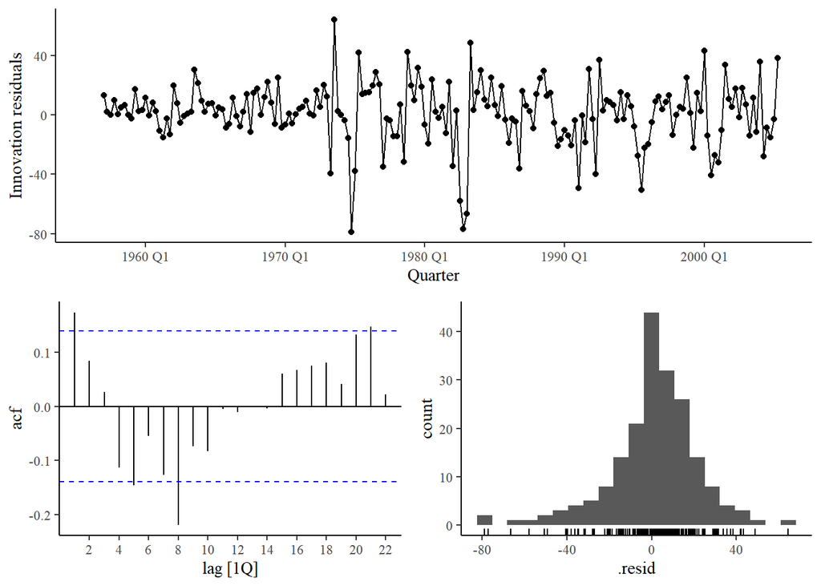

```r
bricks_dcmp %>%
  gg_tsresiduals()
```

Slight positive autocorrelation

I’ll skip the rest. I want to do regressions.